# Bluesky Data Comparison

Helen Miller

7/5/2018

In this notebook, we explore Bluesky column-integrated values during the Napa fires and compare them with AOD values at the same times, using the example of one satellite image from October 12. Similar plots for Oct 8-12 can be found in `localNotebooks/maiac_0702_blusky_column_integrated.Rmd`.

*Note: To knit this document you must have the bluesky data .nc file downloaded locally. It can be found at https://smoke.airfire.org/bluesky-daily/output/temp_susan/BSF_201710_CA/ When knitting, indicate the path where it is located as the parameter bluskyPath*

These plots use data from the Bluesky column-integrated run for the Napa valley fires. For comparing with AOD, several transformations are performed. First, the data is smoothed temporally by taking the surrounding 3-hour mean value at each grid cell, then spatially by taking the mean of the surrounding 3x3 square for each grid cell. The funciton `createBlueskyRasterSlice()` automatically performs these actions.

Next, AOD values are derived from the Bluesky average PM2.5 values using the equation below, which assumes the following:

1. dry atmosphere
2. PM2.5 is only from fire
3. 80% PM2.5 is organic carbon
4. 20% PM2.5 is elemental carbon
5. sulfate/nitrate/unspecified/coursePM/sea salt are negligible

$$AOD = b_{ext}*10000 \\\text{where}\\
b_{ext} = 0.0052\cdot{PM2.5}$$

## Scatterplot of values

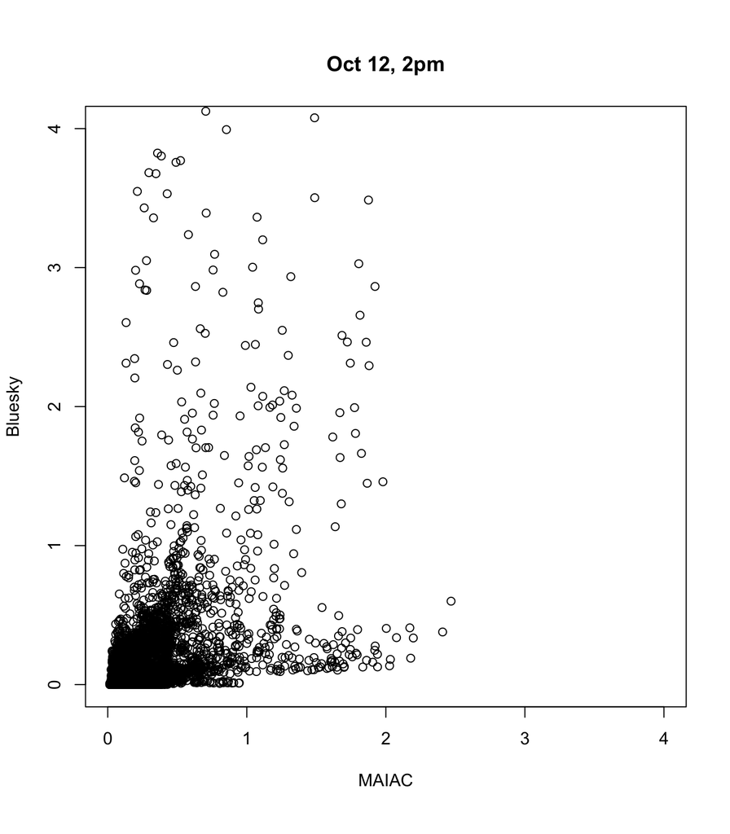

## Maps

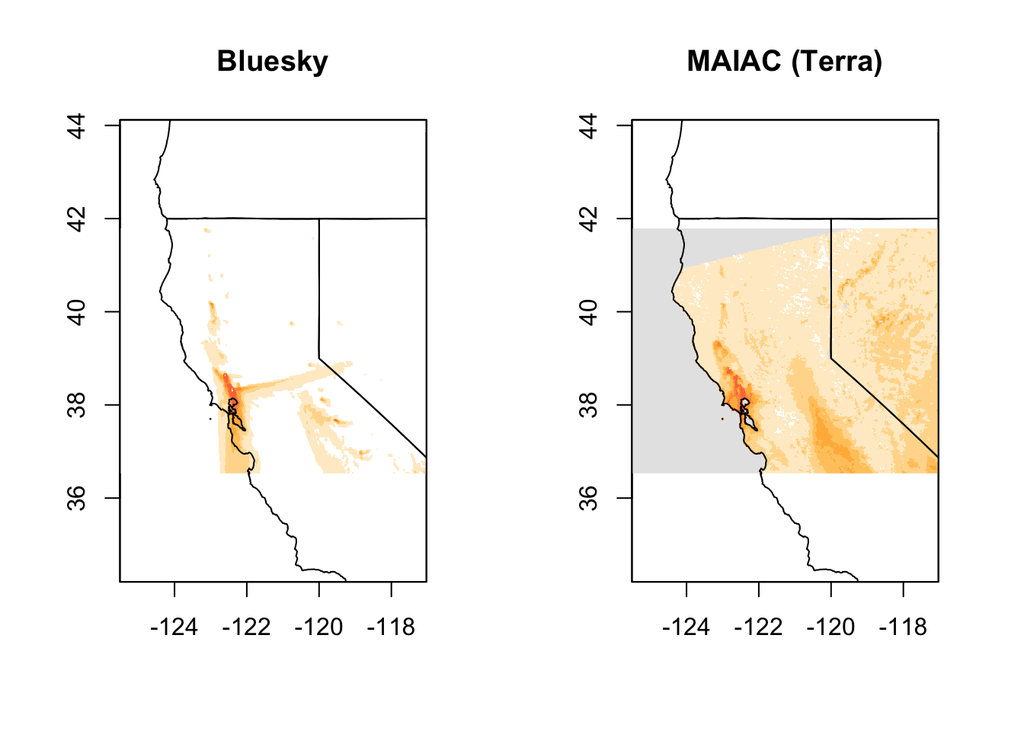

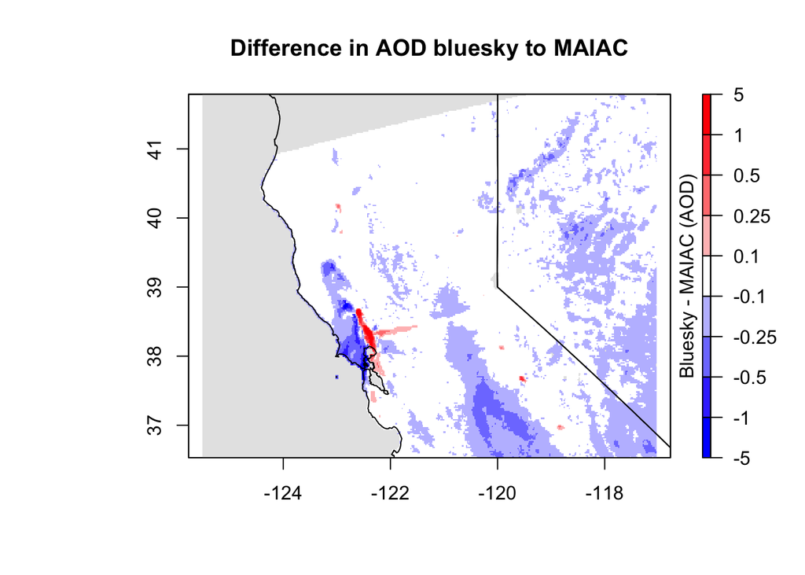